# R Notebook

```r
library(readr)
library(dplyr)
library(stringi)
library(car)
DF <- read_csv("Respuestas.csv")
DF
```

| ¿Cuántos años tienes? | Carrera Universitaria. Escoja su carrera | Seleccione su sexo. | ¿En qué zona de lima reside usted? | Personalidad. Respecto a estas 2 opciones, ¿ cuál consideras que es tu personalidad ? | Numero de cursos. ¿ Cuántos cursos estas llevando ? | Ciclo académico. ¿En que ciclo te encuentras ahora? | De la escala del 1 al 5, ¿ qué tan dificiles consideras los cursos que te encuentras llevando durante este ciclo ? | Escala de la matricula. ¿ Cual es tu escala asignada ? Nota: - Recuerda que esta encuesta es 100% anónima, por lo que no deberías de preocuparte en brindarnos estos tipos de datos. | Horas de sueño. ¿ Cuántas horas sueles dormir al día en una semana de clases ? Nota: - 2.5 horas = 2 hora y 30 minutos - 3.5 horas = 3 horas y 30 minutos ... - 8.5 horas = 8 horas y 30 minutos. | Horas de ocio. ¿ Cuántas horas al día realizas otras cosas externas al estudio y relacionadas al entretenimiento ? Nota: - 1.5 horas = 1 hora y 30 minutos - 2.5 horas = 2 horas y 30 minutos ... - 8.5 … | Horas de estudio fuera de clases. ¿ Cuanto tiempo le dedicas a las tareas, repasos e investigación ? Nota: - 1.5 horas = 1 hora y 30 minutos - 2.5 horas = 2 horas y 30 minutos ... - 8.5 horas = 8 hora… | Tipo de trasporte. ¿ Qué medio de transporte usas a menudo o como te movilizas hacia la universidad ? | Tiempo de traslado entre su domicilio y UTEC. ¿ Cuánto tiempo (en minutos) te demoras en trasladarte de tu domicilio a la universidad ? Nota: - 60 minutos = 1 hora - 90 minutos = 1 hora y 30 minutos -… | Horas dentro de la universidad. ¿ Cuántas horas pasas dentro de las instalaciones de la universidad regularmente ? | Distancia entre tu casa y la universidad. ¿ A cuántos kilómetros aproximadamente se encuentra tu casa a la universidad ? Nota: - Ingrese su respuesta en decimales, empleando el punto "." | De la escala del 1 al 5, ¿ qué tan a gusto te sientes realizando trabajos grupales ? | De la escala del 1 al 5, ¿ qué tan a gusto te sientes realizando exposiciones en el aula ? | ¿A que grupo perteneces? | Hobbie principal. ¿ De qué tipo de actividad disfrutas más a menudo ? | ¿ Qué tan exhausto te sientes al día ? | Nivel de estrés. De la escala del 1 al 10 ¿ Cuál consideras que es tu nivel de estrés promedio durante un ciclo universitario ? | Calidad de educación previa. ¿ Qué tipo de educación previa consideras tener ? |
| --- | --- | --- | --- | --- | --- | --- | --- | --- | --- | --- | --- | --- | --- | --- | --- | --- | --- | --- | --- | --- | --- | --- |
| 18 | Ingeniería Industrial | Femenina | Zona Sur | Introvertido | 6 | 3 | 5 | D | 7.5 | 5.5 | 3.0 | Bus-Micro | 120 | 8 | 14.30 | 3 | 3 | Estudiante | Artisticos - Dibujo, pintura, teatro, baile, etc. | Ligeramente exhausto | 8 | Secundaria Completa en Colegio Estatal |
| 40 | Ingeniería Civil | Masculino | Zona Sur | Extrovertido | 1 | 1 | 1 | A | 2.0 | 8.5 | 1.0 | Ebike / Scooter electrico | 10 | 1 | 7.00 | 1 | 1 | Estudiante con emprendimiento | Gastronomicos. - Degustacion de comida, preparacion, etc. | Muy exhausto | 1 | Secundaria Completa en Colegio Particular |
| 18 | Ingeniería Mecatrónica | Masculino | Zona Centro | Extrovertido | 8 | 8 | 3 | C | 5.0 | 6.5 | 7.0 | A pie | 20 | 7 | 2.00 | 3 | 4 | Estudiante | Tecnologicos - programacion, videojuegos, robotica, etc. | Exhausto | 6 | Secundaria Completa en Colegio Particular |
| 21 | Ingeniería Mecánica | Masculino | Zona Norte | Introvertido | 5 | 3 | 4 | E | 4.0 | 4.0 | 4.0 | Bus-Micro | 120 | 9 | 25.00 | 4 | 3 | Estudiante | Físicos - basados en deporte, y/o estres muscular, etc.. | Exhausto | 6 | Secundaria Completa en Colegio Estatal |
| 35 | Ingeniería Mecánica | Femenina | Zona Norte | Introvertido | 6 | 7 | 4 | C | 6.5 | 3.0 | 6.0 | Metropolitano | 160 | 3 | 40.00 | 4 | 4 | Estudiante Empleado | Gastronomicos. - Degustacion de comida, preparacion, etc. | Exhausto | 9 | Secundaria Completa en Colegio Estatal |
| 40 | Ciencias de la Computación | Femenina | Zona Norte | Extrovertido | 6 | 4 | 4 | C | 5.0 | 2.0 | 4.0 | Bus-Micro | 115 | 6 | 13.00 | 3 | 3 | Estudiante Empleado | Artisticos - Dibujo, pintura, teatro, baile, etc. | Exhausto | 7 | Secundaria Completa en Colegio Estatal |
| 40 | Ingeniería Mecánica | Masculino | Zona Norte | Extrovertido | 6 | 3 | 3 | B | 5.0 | 1.5 | 4.0 | Bus-Micro | 80 | 4 | 15.00 | 2 | 2 | Estudiante | Físicos - basados en deporte, y/o estres muscular, etc.. | Ligeramente exhausto | 3 | Secundaria Completa en Colegio Estatal |
| 24 | Ingeniería Industrial | Femenina | Zona Norte | Extrovertido | 5 | 6 | 3 | D | 7.0 | 2.0 | 1.5 | Bus-Micro | 110 | 9 | 40.00 | 3 | 3 | Estudiante Empleado | Gastronomicos. - Degustacion de comida, preparacion, etc. | Ligeramente exhausto | 3 | Secundaria Completa en Colegio Estatal |
| 40 | Administración y Negocios Digitales | Femenina | Zona Norte | Extrovertido | 6 | 3 | 3 | A | 6.5 | 1.0 | 2.0 | Bus-Micro | 70 | 6 | 15.00 | 4 | 4 | Estudiante Empleado | Tecnologicos - programacion, videojuegos, robotica, etc. | Ligeramente exhausto | 5 | Secundaria Completa en Colegio Estatal |
| 18 | Ingeniería Mecánica | Masculino | Zona Centro | Introvertido | 6 | 3 | 3 | D | 6.0 | 4.5 | 4.5 | Metropolitano | 80 | 4 | 10.90 | 3 | 2 | Estudiante | Tecnologicos - programacion, videojuegos, robotica, etc. | Ligeramente exhausto | 7 | Secundaria Completa en Colegio Particular |

[output cut: 143 more lines]

```r
#limpieza

DF[13,]
```

| ¿Cuántos años tienes? | Carrera Universitaria. Escoja su carrera | Seleccione su sexo. | ¿En qué zona de lima reside usted? | Personalidad. Respecto a estas 2 opciones, ¿ cuál consideras que es tu personalidad ? | Numero de cursos. ¿ Cuántos cursos estas llevando ? | Ciclo académico. ¿En que ciclo te encuentras ahora? | De la escala del 1 al 5, ¿ qué tan dificiles consideras los cursos que te encuentras llevando durante este ciclo ? | Escala de la matricula. ¿ Cual es tu escala asignada ? Nota: - Recuerda que esta encuesta es 100% anónima, por lo que no deberías de preocuparte en brindarnos estos tipos de datos. | Horas de sueño. ¿ Cuántas horas sueles dormir al día en una semana de clases ? Nota: - 2.5 horas = 2 hora y 30 minutos - 3.5 horas = 3 horas y 30 minutos ... - 8.5 horas = 8 horas y 30 minutos. | Horas de ocio. ¿ Cuántas horas al día realizas otras cosas externas al estudio y relacionadas al entretenimiento ? Nota: - 1.5 horas = 1 hora y 30 minutos - 2.5 horas = 2 horas y 30 minutos ... - 8.5 … | Horas de estudio fuera de clases. ¿ Cuanto tiempo le dedicas a las tareas, repasos e investigación ? Nota: - 1.5 horas = 1 hora y 30 minutos - 2.5 horas = 2 horas y 30 minutos ... - 8.5 horas = 8 hora… | Tipo de trasporte. ¿ Qué medio de transporte usas a menudo o como te movilizas hacia la universidad ? | Tiempo de traslado entre su domicilio y UTEC. ¿ Cuánto tiempo (en minutos) te demoras en trasladarte de tu domicilio a la universidad ? Nota: - 60 minutos = 1 hora - 90 minutos = 1 hora y 30 minutos -… | Horas dentro de la universidad. ¿ Cuántas horas pasas dentro de las instalaciones de la universidad regularmente ? | Distancia entre tu casa y la universidad. ¿ A cuántos kilómetros aproximadamente se encuentra tu casa a la universidad ? Nota: - Ingrese su respuesta en decimales, empleando el punto "." | De la escala del 1 al 5, ¿ qué tan a gusto te sientes realizando trabajos grupales ? | De la escala del 1 al 5, ¿ qué tan a gusto te sientes realizando exposiciones en el aula ? | ¿A que grupo perteneces? | Hobbie principal. ¿ De qué tipo de actividad disfrutas más a menudo ? | ¿ Qué tan exhausto te sientes al día ? | Nivel de estrés. De la escala del 1 al 10 ¿ Cuál consideras que es tu nivel de estrés promedio durante un ciclo universitario ? | Calidad de educación previa. ¿ Qué tipo de educación previa consideras tener ? |
| --- | --- | --- | --- | --- | --- | --- | --- | --- | --- | --- | --- | --- | --- | --- | --- | --- | --- | --- | --- | --- | --- | --- |
| 20 | NA | Masculino | Zona Centro | Introvertido | 6 | 3 | 5 | E | 4 | 6.5 | 9 | Metropolitano | 120 | 10 | 17 | 1 | 1 | Estudiante | Físicos - basados en deporte, y/o estres muscular, etc.. | Muy exhausto | 10 | Secundaria Completa en Colegio Estatal |

```r
filas_inservibles <- which(rowSums(is.na(DF)) >= 1)
filas_inservibles
```

```
## [1] 13
```

```r
DF[-filas_inservibles,] -> DF

DF
```

| ¿Cuántos años tienes? | Carrera Universitaria. Escoja su carrera | Seleccione su sexo. | ¿En qué zona de lima reside usted? | Personalidad. Respecto a estas 2 opciones, ¿ cuál consideras que es tu personalidad ? | Numero de cursos. ¿ Cuántos cursos estas llevando ? | Ciclo académico. ¿En que ciclo te encuentras ahora? | De la escala del 1 al 5, ¿ qué tan dificiles consideras los cursos que te encuentras llevando durante este ciclo ? | Escala de la matricula. ¿ Cual es tu escala asignada ? Nota: - Recuerda que esta encuesta es 100% anónima, por lo que no deberías de preocuparte en brindarnos estos tipos de datos. | Horas de sueño. ¿ Cuántas horas sueles dormir al día en una semana de clases ? Nota: - 2.5 horas = 2 hora y 30 minutos - 3.5 horas = 3 horas y 30 minutos ... - 8.5 horas = 8 horas y 30 minutos. | Horas de ocio. ¿ Cuántas horas al día realizas otras cosas externas al estudio y relacionadas al entretenimiento ? Nota: - 1.5 horas = 1 hora y 30 minutos - 2.5 horas = 2 horas y 30 minutos ... - 8.5 … | Horas de estudio fuera de clases. ¿ Cuanto tiempo le dedicas a las tareas, repasos e investigación ? Nota: - 1.5 horas = 1 hora y 30 minutos - 2.5 horas = 2 horas y 30 minutos ... - 8.5 horas = 8 hora… | Tipo de trasporte. ¿ Qué medio de transporte usas a menudo o como te movilizas hacia la universidad ? | Tiempo de traslado entre su domicilio y UTEC. ¿ Cuánto tiempo (en minutos) te demoras en trasladarte de tu domicilio a la universidad ? Nota: - 60 minutos = 1 hora - 90 minutos = 1 hora y 30 minutos -… | Horas dentro de la universidad. ¿ Cuántas horas pasas dentro de las instalaciones de la universidad regularmente ? | Distancia entre tu casa y la universidad. ¿ A cuántos kilómetros aproximadamente se encuentra tu casa a la universidad ? Nota: - Ingrese su respuesta en decimales, empleando el punto "." | De la escala del 1 al 5, ¿ qué tan a gusto te sientes realizando trabajos grupales ? | De la escala del 1 al 5, ¿ qué tan a gusto te sientes realizando exposiciones en el aula ? | ¿A que grupo perteneces? | Hobbie principal. ¿ De qué tipo de actividad disfrutas más a menudo ? | ¿ Qué tan exhausto te sientes al día ? | Nivel de estrés. De la escala del 1 al 10 ¿ Cuál consideras que es tu nivel de estrés promedio durante un ciclo universitario ? | Calidad de educación previa. ¿ Qué tipo de educación previa consideras tener ? |
| --- | --- | --- | --- | --- | --- | --- | --- | --- | --- | --- | --- | --- | --- | --- | --- | --- | --- | --- | --- | --- | --- | --- |
| 18 | Ingeniería Industrial | Femenina | Zona Sur | Introvertido | 6 | 3 | 5 | D | 7.5 | 5.5 | 3.0 | Bus-Micro | 120 | 8 | 14.30 | 3 | 3 | Estudiante | Artisticos - Dibujo, pintura, teatro, baile, etc. | Ligeramente exhausto | 8 | Secundaria Completa en Colegio Estatal |
| 40 | Ingeniería Civil | Masculino | Zona Sur | Extrovertido | 1 | 1 | 1 | A | 2.0 | 8.5 | 1.0 | Ebike / Scooter electrico | 10 | 1 | 7.00 | 1 | 1 | Estudiante con emprendimiento | Gastronomicos. - Degustacion de comida, preparacion, etc. | Muy exhausto | 1 | Secundaria Completa en Colegio Particular |
| 18 | Ingeniería Mecatrónica | Masculino | Zona Centro | Extrovertido | 8 | 8 | 3 | C | 5.0 | 6.5 | 7.0 | A pie | 20 | 7 | 2.00 | 3 | 4 | Estudiante | Tecnologicos - programacion, videojuegos, robotica, etc. | Exhausto | 6 | Secundaria Completa en Colegio Particular |
| 21 | Ingeniería Mecánica | Masculino | Zona Norte | Introvertido | 5 | 3 | 4 | E | 4.0 | 4.0 | 4.0 | Bus-Micro | 120 | 9 | 25.00 | 4 | 3 | Estudiante | Físicos - basados en deporte, y/o estres muscular, etc.. | Exhausto | 6 | Secundaria Completa en Colegio Estatal |
| 35 | Ingeniería Mecánica | Femenina | Zona Norte | Introvertido | 6 | 7 | 4 | C | 6.5 | 3.0 | 6.0 | Metropolitano | 160 | 3 | 40.00 | 4 | 4 | Estudiante Empleado | Gastronomicos. - Degustacion de comida, preparacion, etc. | Exhausto | 9 | Secundaria Completa en Colegio Estatal |
| 40 | Ciencias de la Computación | Femenina | Zona Norte | Extrovertido | 6 | 4 | 4 | C | 5.0 | 2.0 | 4.0 | Bus-Micro | 115 | 6 | 13.00 | 3 | 3 | Estudiante Empleado | Artisticos - Dibujo, pintura, teatro, baile, etc. | Exhausto | 7 | Secundaria Completa en Colegio Estatal |
| 40 | Ingeniería Mecánica | Masculino | Zona Norte | Extrovertido | 6 | 3 | 3 | B | 5.0 | 1.5 | 4.0 | Bus-Micro | 80 | 4 | 15.00 | 2 | 2 | Estudiante | Físicos - basados en deporte, y/o estres muscular, etc.. | Ligeramente exhausto | 3 | Secundaria Completa en Colegio Estatal |
| 24 | Ingeniería Industrial | Femenina | Zona Norte | Extrovertido | 5 | 6 | 3 | D | 7.0 | 2.0 | 1.5 | Bus-Micro | 110 | 9 | 40.00 | 3 | 3 | Estudiante Empleado | Gastronomicos. - Degustacion de comida, preparacion, etc. | Ligeramente exhausto | 3 | Secundaria Completa en Colegio Estatal |
| 40 | Administración y Negocios Digitales | Femenina | Zona Norte | Extrovertido | 6 | 3 | 3 | A | 6.5 | 1.0 | 2.0 | Bus-Micro | 70 | 6 | 15.00 | 4 | 4 | Estudiante Empleado | Tecnologicos - programacion, videojuegos, robotica, etc. | Ligeramente exhausto | 5 | Secundaria Completa en Colegio Estatal |
| 18 | Ingeniería Mecánica | Masculino | Zona Centro | Introvertido | 6 | 3 | 3 | D | 6.0 | 4.5 | 4.5 | Metropolitano | 80 | 4 | 10.90 | 3 | 2 | Estudiante | Tecnologicos - programacion, videojuegos, robotica, etc. | Ligeramente exhausto | 7 | Secundaria Completa en Colegio Particular |

[output cut: 142 more lines]

```r
edad  <- DF$`¿Cuántos años tienes?`

horas_de_estudio_por_persona_al_dia <- DF$`Horas de estudio fuera de clases.  ¿ Cuanto tiempo le dedicas a las tareas, repasos e investigación ?

Nota:
-  1.5 horas  =  1 hora y 30 minutos
-  2.5 horas  =  2 horas y 30 minutos
                      ...
-  8.5 horas  =  8 horas y 30 minutos.`


nivel_de_estres_a_escala <-  DF$`Nivel de estrés. De la escala del 1 al 10 ¿ Cuál consideras que es tu nivel de estrés promedio durante un ciclo universitario  ?`

promedio_de_cant_cursos <- mean(DF$`Numero de cursos. ¿ Cuántos cursos estas llevando ?`, na.rm=TRUE)



horas_de_sueño <- DF$`Horas de sueño. ¿ Cuántas horas sueles dormir al día en una semana de clases ?

Nota:
-  2.5 horas  =  2 hora y 30 minutos
-  3.5 horas  =  3 horas y 30 minutos
                      ...
-  8.5 horas  =  8 horas y 30 minutos.`


horas_de_ocio <-  DF$`Horas de ocio.  ¿ Cuántas  horas al día  realizas otras cosas externas al estudio y relacionadas al entretenimiento ?

Nota:
-  1.5 horas  =  1 hora y 30 minutos
-  2.5 horas  =  2 horas y 30 minutos
                      ...
-  8.5 horas  =  8 horas y 30 minutos.`



intensidad_de_los_cursos <-  DF$`De la escala del 1 al 5, ¿ qué tan dificiles consideras los cursos que te encuentras llevando  durante este ciclo ?`

ciclo_academico <-  DF$`Ciclo académico. ¿En que ciclo te encuentras ahora?`


cantidad_De_cursos <-  DF$`Numero de cursos. ¿ Cuántos cursos estas llevando ?`




Distancia_UTEC_entre_CASA <- DF$`Distancia entre tu casa y la universidad. ¿  A cuántos kilómetros aproximadamente se encuentra tu casa a la universidad ?

Nota:
- Ingrese su respuesta en decimales, empleando el  punto "."`



tiempo_de_traslado_entre_casa_y_utec <-  DF$`Tiempo de traslado entre su domicilio y UTEC.  ¿ Cuánto tiempo (en minutos) te demoras en trasladarte de tu domicilio a la universidad ?

Nota:

- 60 minutos = 1 hora

- 90 minutos = 1 hora y 30 minutos

- 120  minutos = 2 horas

- 150 minutos = 2 horas y 30 minutos

- 160 minutos = 3 horas`


calidad_de_educacion_previa <-  DF$`Calidad de educación previa. ¿ Qué tipo de educación previa consideras tener ?`

medio_de_trasporte <- DF$`Tipo de trasporte. ¿ Qué medio de transporte usas a menudo o como te movilizas hacia la universidad ?`
```

## Introducción

### Relevancia

El estrés es una preocupación creciente en el ámbito académico, y comprender sus causas y efectos en esta población específica es fundamental para mejorar su bienestar y rendimiento. A través de un enfoque probabilístico, es posible identificar los factores de riesgo y las variables más influyentes en la manifestación del estrés, así como evaluar su impacto en diferentes grupos de estudiantes. En este analisis estadístico buscamos encontrar patrones y tendencias, lo que facilita la implementación de estrategias de prevención y apoyo específicas.

### Objetivos

-Describir e identificar las situaciones, actividades y características propias de la vida universitaria , para así, relacionarlas con el estrés estudiantil.

-Relacionar los factores comunes entre los estudiantes que reporten mayores o menores niveles de estrés, y así, comparar y determinar el nivel en que las distintas variables están generando estrés en ellos.

-Comprender las características de los estudiantes que presentan niveles bajos y altos de estrés.

### Contexto

En la vida universitaria, los estudiantes se enfrentan a una serie de retos y experiencias que los moldean como profesionales y seres humanos. Para el ciclo 2023- 1, la vida universitaria se caracteriza generalmente por una carga académica exigente, la necesidad de gestionar el tiempo de manera eficiente, la participación en actividades extracurriculares, el establecimiento de relaciones sociales y la búsqueda de equilibrio entre el estudio y el disfrute de la vida estudiantil.

Este proceso implica que muchos de los estudiantes enfrenten desafíos como manejar el estrés, vivir a cierta distancia de la universidad, teniendo que enfrentarse al tráfico para cumplir con sus responsabilidades académicas y personales. Así también existe una alta intensidad y exigencia.

Este estudio nos permite también desarrollar un ámbito probabilístico ya que cuando hacemos una distribución de de probabilidad del nivel de estrés, podemos modelar el nivel de estrés como la variable aleatoria y analizar su distribución de probabilidad. Por otro lado también se pueden generar predicciones con la finalidad de que una institución educativa se anticipe y afronte la problemática de manera efectiva.

## Probabilidades

### Probabilidad empirica

**1.Niveles de estres de los estudiantes UTEC del 2023-1**

**Experimento** Seleccionar aleatoriamente un participante del estudio “Análisis de los factores y actividades propias de la vida universitaria, y su relación con el desarrollo del estrés en los estudiantes de la UTEC durante el periodo 2023-1”.y observar su respuesta respecto a cual fue su nivel de estrés durante el periodo 2023-1.

**Estapacio muestral** Ω={1, 2 ,3 ,4 ,5 ,6, 7, 8, 9, 10}

**Eventos Atómicos** A1: nivel de estres 1 A2: nivel de estres 2 A3: nivel de estres 3 A4: nivel de estres 4 A5: nivel de estres 5 A6: nivel de estres 6 A7: nivel de estres 7 A8: nivel de estres 8 A9: nivel de estres 9 A10: nivel de estres 10

Donde cada evento atómico significa:

**A1** ->: Seleccionar un participante del estudio “Análisis de los factores y actividades propias de la vida universitaria, y su relación con el desarrollo del estrés en los estudiantes de la UTEC durante el periodo 2023-1”y observar que su nivel de estrés es 1. P(A1)=f(A1)/153.

**A2** -> : Seleccionar un participante del estudio “Análisis de los factores y actividades propias de la vida universitaria, y su relación con el desarrollo del estrés en los estudiantes de la UTEC durante el periodo 2023-1”y observar que su nivel de estrés es 2 .P(A2)=f(A2)/153. . **A3** ->: Seleccionar un participante del estudio “Análisis de los factores y actividades propias de la vida universitaria, y su relación con el desarrollo del estrés en los estudiantes de la UTEC durante el periodo 2023-1”y observar que su nivel de estrés es 3 .P(A3)=f(A3)/153.

**A4** ->: Seleccionar un participante del estudio “Análisis de los factores y actividades propias de la vida universitaria, y su relación con el desarrollo del estrés en los estudiantes de la UTEC durante el periodo 2023-1”y observar que su nivel de estrés es 4. P(A4)=f(A4)/153.

**A5** -> : Seleccionar un participante del estudio “Análisis de los factores y actividades propias de la vida universitaria, y su relación con el desarrollo del estrés en los estudiantes de la UTEC durante el periodo 2023-1”y observar que su nivel de estrés es 5. P(A5)=f(A5)/153.

**A6** ->: Seleccionar un participante del estudio “Análisis de los factores y actividades propias de la vida universitaria, y su relación con el desarrollo del estrés en los estudiantes de la UTEC durante el periodo 2023-1”y observar que su nivel de estrés es 6. P(6A)=f(A6)/153.

**A7** -> : Seleccionar un participante del estudio “Análisis de los factores y actividades propias de la vida universitaria, y su relación con el desarrollo del estrés en los estudiantes de la UTEC durante el periodo 2023-1”y observar que su nivel de estrés es 7. P(A7)=f(A7)/153.

**A8** ->: Seleccionar un participante del estudio “Análisis de los factores y actividades propias de la vida universitaria, y su relación con el desarrollo del estrés en los estudiantes de la UTEC durante el periodo 2023-1”y observar que su nivel de estrés es 8 .P(A8)=f(A8)/153.

**A9** -> : Seleccionar un participante del estudio “Análisis de los factores y actividades propias de la vida universitaria, y su relación con el desarrollo del estrés en los estudiantes de la UTEC durante el periodo 2023-1”y observar que su nivel de estrés es 9. P(9)=f(A9)/153.

**A10** ->: Seleccionar un participante del estudio “Análisis de los factores y actividades propias de la vida universitaria, y su relación con el desarrollo del estrés en los estudiantes de la UTEC durante el periodo 2023-1”y observar que su nivel de estrés es 10 .P(A10)=f(A10)/153.

**Probabilidades asociadas a cada evento: P(An)=f(An)/154** Frecuencia con la que ocurre el evento según nivel de estrés del 1 al 10

```r
table(nivel_de_estres_a_escala)
```

```
## nivel_de_estres_a_escala
##  1  2  3  4  5  6  7  8  9 10
##  5  6  9  9 12 13 31 30 20 17
```

En este caso el espacio de resultados teórico sería el conjunto de todas las posibles respuestas que las personas han dado en la encuesta sobre el nivel de estrés que ellos presentan.

Calculamos la función de probabilidad dividiendo las frecuencias de cada nivel de estrés por el total de personas encuestadas (153), hallamos un nivel de estrés individual.

P(1) P(2) P(3) P(4) P(5) P(6) P(7) P(8) P(9) P(10) 0.03 0.04 0.06 0.06 0.08 0.08 0.20 0.20 0.13 0.12

##La probabilidad de que se tome un nivel de estrés 7 y 8 son mayores que las demás, ya que presentan un 20%

**2.Número de cursos que llevan los estudiantes UTEC del 2023-1**

**Experimento** Seleccionar aleatoriamente un participante del estudio “Análisis de los factores y actividades propias de la vida universitaria, y su relación con el desarrollo del estrés en los estudiantes de la UTEC durante el periodo 2023-1”.y observar su respuesta respecto a cual es la cantidad de cursos que esta llevando durante el periodo 2023-1.

**Estapacio muestral** Ω={1, 2 ,3 ,4 ,5 ,6, 7, 8}

**Eventos Atómicos** A1:Que lleven 1 curso A2:Que lleven 2 curso A3:Que lleven 3 curso A4:Que lleven 4 curso A5:Que lleven 5 curso A6:Que lleven 6 curso A7:Que lleven 7 curso A8:Que lleven 8 curso

Donde cada evento atómico significa:

**A1** ->: Seleccionar un participante del estudio “Análisis de los factores y actividades propias de la vida universitaria, y su relación con el desarrollo del estrés en los estudiantes de la UTEC durante el periodo 2023-1”y observar que su respuesta es 1 curso. P(A1)=f(A1)/153.

**A2** -> : Seleccionar un participante del estudio “Análisis de los factores y actividades propias de la vida universitaria, y su relación con el desarrollo del estrés en los estudiantes de la UTEC durante el periodo 2023-1”y observar que su respuesta es 2 cursos. P(A2)=f(A2)/153. . **A3** ->: Seleccionar un participante del estudio “Análisis de los factores y actividades propias de la vida universitaria, y su relación con el desarrollo del estrés en los estudiantes de la UTEC durante el periodo 2023-1”y observar que su respuesta es 3 cursos. .P(A3)=f(A3)/153.

**A4** ->: Seleccionar un participante del estudio “Análisis de los factores y actividades propias de la vida universitaria, y su relación con el desarrollo del estrés en los estudiantes de la UTEC durante el periodo 2023-1”y observar que su respuesta es 4 cursos. P(A4)=f(A4)/153.

**A5** -> : Seleccionar un participante del estudio “Análisis de los factores y actividades propias de la vida universitaria, y su relación con el desarrollo del estrés en los estudiantes de la UTEC durante el periodo 2023-1”y observar que su respuesta es 5 cursos. P(A5)=f(A5)/153.

**A6** ->: Seleccionar un participante del estudio “Análisis de los factores y actividades propias de la vida universitaria, y su relación con el desarrollo del estrés en los estudiantes de la UTEC durante el periodo 2023-1”y observar que su respuesta es 6 cursos. P(6A)=f(A6)/153.

**A7** -> : Seleccionar un participante del estudio “Análisis de los factores y actividades propias de la vida universitaria, y su relación con el desarrollo del estrés en los estudiantes de la UTEC durante el periodo 2023-1”y observar que su respuesta es 7 cursos. P(A7)=f(A7)/153.

**A8** ->: Seleccionar un participante del estudio “Análisis de los factores y actividades propias de la vida universitaria, y su relación con el desarrollo del estrés en los estudiantes de la UTEC durante el periodo 2023-1”y observar que su respuesta es 8 cursos .P(A8)=f(A8)/153.

**Probabilidades asociadas a cada evento: P(An)=f(An)/154** Frecuencia con la que ocurre el evento según la cantidad de cursos 1 al 8.

```r
table(cantidad_De_cursos)
```

```
## cantidad_De_cursos
##  1  2  3  4  5  6  7  8
##  2  3  2 10 42 67 19  7
```

### Probabilidad condicional

#### Independientes:

##### Primer par

Evento A: El estudiante utiliza el modo de transporte público o privado.

Evento B: El estudiante presenta un nivel de estrés mayor a 5.

Datos proporcionados:

```r
total_estudiantes <- 153
estudiantes_transportepublico <- 105
estudiantes_transporteprivado <- 48
estudiantes_estres_mayor5_publico <- 93
estudiantes_estres_menor_igual3_privado <- 48
```

Cálculo de probabilidades

```r
P_A <- (estudiantes_transportepublico + estudiantes_transporteprivado) / total_estudiantes
P_B <- (estudiantes_estres_mayor5_publico + estudiantes_estres_menor_igual3_privado) / total_estudiantes
P_A_interseccion_B <- estudiantes_estres_mayor5_publico / total_estudiantes

P_B_dado_A <- P_A_interseccion_B / P_A

P_B_dado_no_A <- (estudiantes_estres_menor_igual3_privado) / (total_estudiantes - estudiantes_transportepublico)
P_no_A <- 1 - P_A

P_B <- P_B_dado_A * P_A + P_B_dado_no_A * P_no_A

P_A_dado_B <- (P_B_dado_A * P_A) / P_B
```

Resultados:

```r
cat("La probabilidad condicional P(B|A) es aproximadamente", round(P_B_dado_A, 3), "\n")
```

```
## La probabilidad condicional P(B|A) es aproximadamente 0.608
```

```r
cat("La probabilidad condicional P(A|B) es aproximadamente", round(P_A_dado_B, 3), "\n")
```

```
## La probabilidad condicional P(A|B) es aproximadamente 1
```

Por lo tanto, después de aplicar el teorema de Bayes y la probabilidad total, validamos los resultados anteriores:

La probabilidad condicional P(B|A) es igual a 0.608, lo que indica que si un estudiante utiliza el modo de transporte público o privado (evento A), la probabilidad de que tenga un nivel de estrés mayor a 5 (evento B) es del 60.8%.

La probabilidad condicional P(A|B) es igual a 1, lo que indica que si un estudiante tiene un nivel de estrés mayor a 5 (evento B), la probabilidad de que utilice el modo de transporte público o privado (evento A) es del 100%.

**Gráfico de Dependencia: Transporte y Estrés**

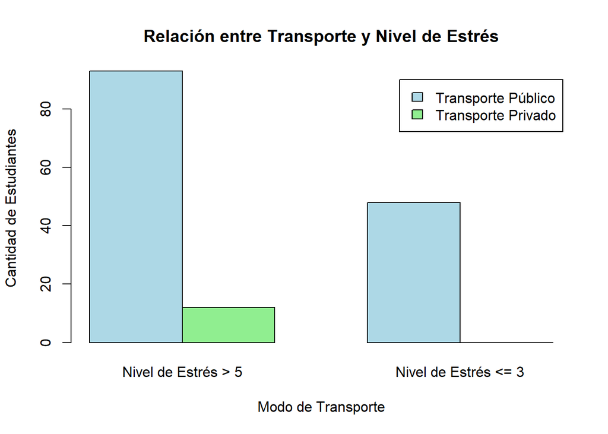

```r
# Crear una tabla de contingencia
tabla <- matrix(c(estudiantes_estres_mayor5_publico, estudiantes_estres_menor_igual3_privado,
                  estudiantes_transportepublico - estudiantes_estres_mayor5_publico, estudiantes_transporteprivado - estudiantes_estres_menor_igual3_privado),
                nrow = 2, byrow = TRUE)

# Agregar etiquetas a las filas y columnas
colnames(tabla) <- c("Nivel de Estrés > 5", "Nivel de Estrés <= 3")
rownames(tabla) <- c("Transporte Público", "Transporte Privado")

# Crear un gráfico de barras apiladas
barplot(tabla, beside = TRUE, col = c("lightblue", "lightgreen"), legend = rownames(tabla),
        main = "Relación entre Transporte y Nivel de Estrés",
        xlab = "Modo de Transporte", ylab = "Cantidad de Estudiantes")
```

El gráfico de barras apiladas muestra la relación entre el modo de transporte (público y privado) y el nivel de estrés de los estudiantes. Cada barra representa la cantidad de estudiantes en cada categoría. Las barras correspondientes a cada modo de transporte y nivel de estrés son significativamente diferentes en altura, esto respaldaría la dependencia entre los eventos.

##### Segundo par

Evento A: El estudiante vive en zona sur o zona norte. Evento B: El estudiante presenta un nivel de estrés mayor a 5.

Datos proporcionados:

```r
total_estudiantes <- 153
estudiantes_sur <- 79
estudiantes_norte <- 74
estres_sur <- 53
estres_norte <- 40
```

Cálculo de probabilidades

```r
P_A <- (estudiantes_sur + estudiantes_norte) / total_estudiantes
P_B <- (estres_sur + estres_norte) / total_estudiantes
P_A_interseccion_B <- (estres_sur + estres_norte) / total_estudiantes

P_B_dado_A <- P_A_interseccion_B / P_A

P_B_dado_no_A <- 0
P_no_A <- 0

P_B <- P_B_dado_A * P_A + P_B_dado_no_A * P_no_A

P_A_dado_B <- (P_B_dado_A * P_A) / P_B
```

Resultados

```r
cat("La probabilidad condicional P(B|A) es aproximadamente", round(P_B_dado_A, 3), "\n")
```

```
## La probabilidad condicional P(B|A) es aproximadamente 0.608
```

```r
cat("La probabilidad condicional P(A|B) es aproximadamente", round(P_A_dado_B, 3), "\n")
```

```
## La probabilidad condicional P(A|B) es aproximadamente 1
```

Por lo tanto, después de aplicar el teorema de Bayes y la probabilidad total, validamos los resultados anteriores:

**Gráfico de Independencia: Zona de Residencia y Estrés**

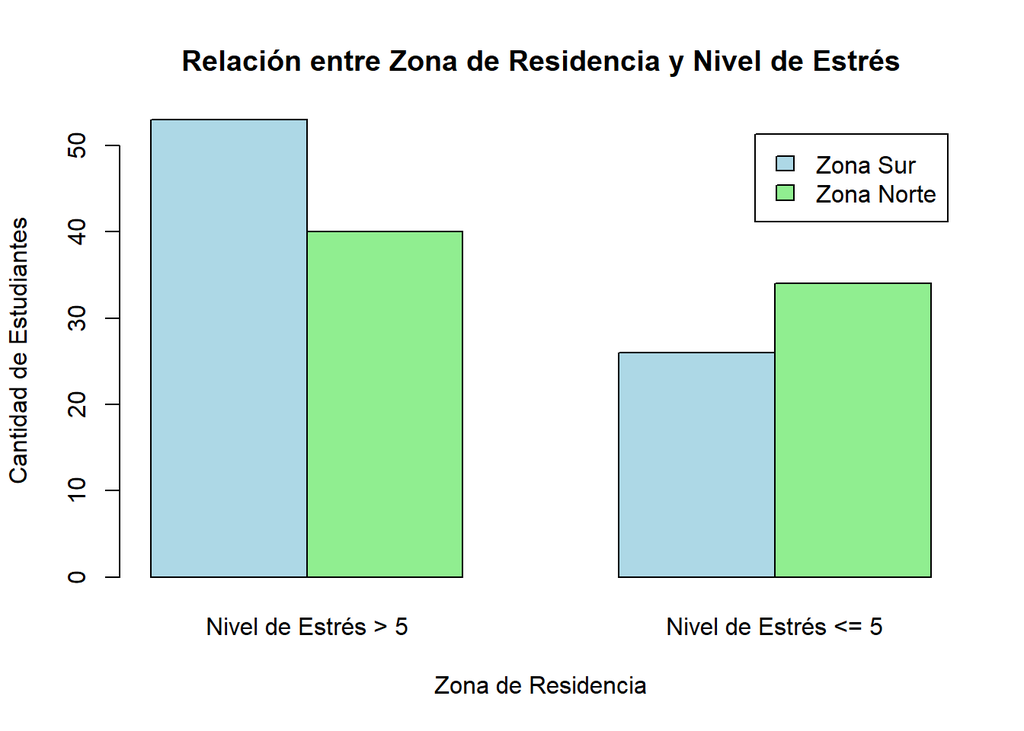

```r
# Crear una tabla de contingencia
tabla <- matrix(c(estres_sur, estudiantes_sur - estres_sur,
                  estres_norte, estudiantes_norte - estres_norte),
                nrow = 2, byrow = TRUE)

# Agregar etiquetas a las filas y columnas
colnames(tabla) <- c("Nivel de Estrés > 5", "Nivel de Estrés <= 5")
rownames(tabla) <- c("Zona Sur", "Zona Norte")

# Crear un gráfico de barras apiladas
barplot(tabla, beside = TRUE, col = c("lightblue", "lightgreen"), legend = rownames(tabla),
        main = "Relación entre Zona de Residencia y Nivel de Estrés",
        xlab = "Zona de Residencia", ylab = "Cantidad de Estudiantes")
```

Interpretación: Los resultados sugieren que hay una relación entre la zona de residencia de los estudiantes y su nivel de estrés. Un mayor porcentaje de estudiantes que viven en la zona sur presenta un nivel de estrés mayor a 5 en comparación con los estudiantes que viven en la zona norte.

#### Dependientes:

##### Primer par

Dependientes:

De los datos obtenidos en la encuesta, tenemos un total de 153 estudiantes, de los cuales 99 reportan altos niveles de estrés. De estos, 79 duermen 6 horas o menos. Además, 29 estudiantes se encuentran en ciclos avanzados y 94 llevan una alta cantidad de cursos. Se observa que de los 79 estudiantes que duermen poco, 45 de ellos llevan una alta cantidad de cursos y 15 están en ciclos académicos avanzados.

Evento A: El estudiante tiene una cantidad alta de cursos. Evento B: El estudiante duerme menos de 6 horas al día.

Datos proporcionados:

```r
total_estudiantes <- 153
estudiantes_duermenpoco<- 79
estudiantes_altacantidad <- 94
estudiantes_duermenpocoaltacantidad <- 45


# Cálculo de probabilidades
P_A <- (estudiantes_altacantidad) / total_estudiantes
P_B <- (estudiantes_duermenpoco ) / total_estudiantes
P_A_interseccion_B <- estudiantes_duermenpocoaltacantidad / total_estudiantes

P_B_dado_A <- P_A_interseccion_B / P_A

P_B_dado_no_A <- (estudiantes_duermenpoco - estudiantes_duermenpocoaltacantidad) / (total_estudiantes - estudiantes_altacantidad)
P_no_A <- 1 - P_A

P_B <- P_B_dado_A * P_A + P_B_dado_no_A * P_no_A

P_A_dado_B <- (P_B_dado_A * P_A) / P_B
```

Resultados

```r
cat("La probabilidad condicional P(B|A) es aproximadamente", round(P_B_dado_A, 3), "\n")
```

```
## La probabilidad condicional P(B|A) es aproximadamente 0.479
```

```r
cat("La probabilidad condicional P(A|B) es aproximadamente", round(P_A_dado_B, 3), "\n")
```

```
## La probabilidad condicional P(A|B) es aproximadamente 0.57
```

La probabilidad condicional P(B|A) es aproximadamente 0.478, lo que indica que si un estudiante tiene una cantidad alta de cursos (evento A), la probabilidad de que duerma menos de 6 horas al día (evento B) es del 47.8%.

La probabilidad condicional P(A|B) es aproximadamente 0.570, lo que indica que si un estudiante duerme menos de 6 horas al día (evento B), la probabilidad de que tenga una cantidad alta de cursos (evento A) es del 57%.

Interpretación: Los resultados sugieren que existe una relación entre tener una alta cantidad de cursos y dormir menos de 6 horas, y que estos eventos no son independientes. Esto podría implicar que la carga académica afecta negativamente la calidad del sueño de los estudiantes, el cual se sabe que está directamente relacionado con el estrés y la salud mental del estudiante.

#### segundo par

Evento A: El estudiante cursa en ciclos académicos avanzados (6 ciclo a +) Evento B: El estudiante tiene pocas horas de ocio.

Datos proporcionados

```r
total_estudiantes <- 153
estudiantes_cicloavanzado <- 29
estudiantes_pocoocio <- 79
estudiantes_cicloavanzadoestres <- 15
```

Cálculo de probabilidades

```r
P_A <- (estudiantes_cicloavanzado) / total_estudiantes
P_B <- (estudiantes_pocoocio) / total_estudiantes
P_A_interseccion_B <- (estudiantes_cicloavanzadoestres) / total_estudiantes

P_B_dado_A <- P_A_interseccion_B / P_A

P_B_dado_no_A <- (estudiantes_pocoocio -estudiantes_cicloavanzadoestres)/(total_estudiantes-estudiantes_cicloavanzado)

P_no_A <- (1-P_A)

P_B <- P_B_dado_A * P_A + P_B_dado_no_A * P_no_A


P_A_dado_B <- (P_B_dado_A * P_A) / P_B
```

Resultados

```r
cat("La probabilidad condicional P(B|A) es aproximadamente", round(P_B_dado_A, 3), "\n")
```

```
## La probabilidad condicional P(B|A) es aproximadamente 0.517
```

```r
cat("La probabilidad condicional P(A|B) es aproximadamente", round(P_A_dado_B, 3), "\n")
```

```
## La probabilidad condicional P(A|B) es aproximadamente 0.19
```

La probabilidad condicional P(B|A) es aproximadamente 0.516, lo que indica que si un estudiante se encuentra en ciclos académicos avanzados (evento A), la probabilidad de que tenga pocas horas de ocio (evento B) es del 51.6%.

La probabilidad condicional P(A|B) es aproximadamente 0.190, lo que indica que si un estudiante tiene pocas horas de ocio (evento B), la probabilidad de que se encuentre en ciclos académicos avanzados (evento A) es del 19%.

## Variables Discretas

### Primera variable

Definimos un fracaso y un exito para la variable, porque nos interesa encontrar a los alumnos mas estresados a apartir de sus habitos de sueño.

7 horas o mas para habitos de sueño saludables y menos de 7 para horas de sueño no saludables.

```r
TH = table(horas_de_sueño)
TH
```

```
## horas_de_sueño
##   2   3 3.5   4 4.5   5 5.5   6 6.5   7 7.5   8 8.5   9
##   2   1   2   4   7  20  17  25  21  24  13  10   5   1
```

```r
HabitosSueño = as.data.frame(cbind(sum(TH[0:9]),sum(TH[10:14])))

HabitosSueño = rename(HabitosSueño, HabitosPocoSaludables = V1, HabitosSaludables = V2)

probH = HabitosSueño/152
```

Frecuencias reacomodadas:

```r
HabitosSueño
```

| HabitosPocoSaludables | HabitosSaludables |
| --- | --- |
| 99 | 53 |

Probabilidades:

```r
probH
```

| HabitosPocoSaludables | HabitosSaludables |
| --- | --- |
| 0.6513158 | 0.3486842 |

Entonces definimos una distribucion Binomial : X ~bin(p,n), donde X es el numero de exitos y n la cantidad de intentos

Para la primera variable la definimos como: x = # numero de estudiantes de la universidad UTEC del ciclo 2023-1 que poseen habitos de sueño poco saludables en un conjunto de 152 estudiantes encuestados del ciclo 2023-1 de la universidad Utec .

Entonces identificamos los parámetros para la primera variable,X ~bin(p,n) donde p es la probabilidad de selecionar una persona con habitos de sueño poco saludable y n es el conjunto de 152 estudiantes de la utec.

Ahora construimos la funcion de densidad y la cumulativa.

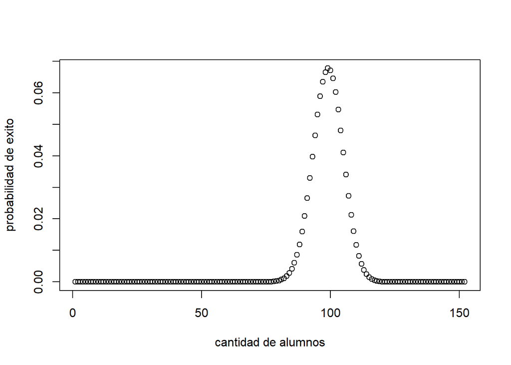

```r
x = 1:152

plot(dbinom(x, 152,as.numeric(probH[1])), ylab = "probabilidad de exito", xlab = "cantidad de alumnos")
```

Funcion de densidad cumulativa

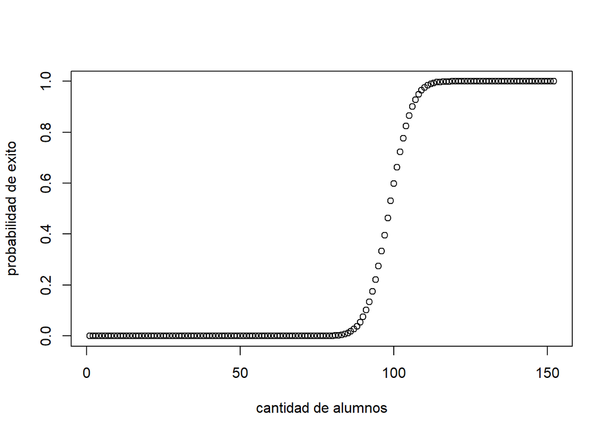

```r
plot(pbinom(x, 152,as.numeric(probH[1])), ylab = "probabilidad de exito", xlab = "cantidad de alumnos")
```

Esperanza:

```r
as.numeric(152*probH[1])
```

```
## [1] 99
```

Varianza:

```r
as.numeric(152*probH[1]*(1-probH[1]))
```

```
## [1] 34.51974
```

Ejemplo:

```r
1 - pbinom(0.75 * 152, 152, 0.75)
```

```
## [1] 0.4688946
```

### Segunda variable

Definimos un fracaso y un exito para variable, porque nos interesa encontrar a los alumnos mas estresados a apartir de las cantidades de cursos que llevan.

```r
TC = table(cantidad_De_cursos)

TC
```

```
## cantidad_De_cursos
##  1  2  3  4  5  6  7  8
##  2  3  2 10 42 67 19  7
```

```r
CargaCursos = as.data.frame(cbind(sum(TC[0:4]),sum(TC[5:8])))

CargaCursos = rename(CargaCursos, CargaLigera = V1, CargaPesada = V2)


probC = CargaCursos/152
```

Frecuencias reacomodadas:

```r
CargaCursos
```

| CargaLigera | CargaPesada |
| --- | --- |
| 17 | 135 |

Probabilidades:

```r
probC
```

| CargaLigera | CargaPesada |
| --- | --- |
| 0.1118421 | 0.8881579 |

Para la segunda variable la definimos como: x = # de estudiantes de la utec que tienen una carga de cursos pesada.

Entonces identificamos los parámetros para la segunda variable, ~bin(p,n) donde p es la probabilidad de selecionar una persona que lleva una carga pesada de cursos y n es el conjunto de los estudiantes de la utec.

Ahora construimos la funcion de densidad y la cumulativa.

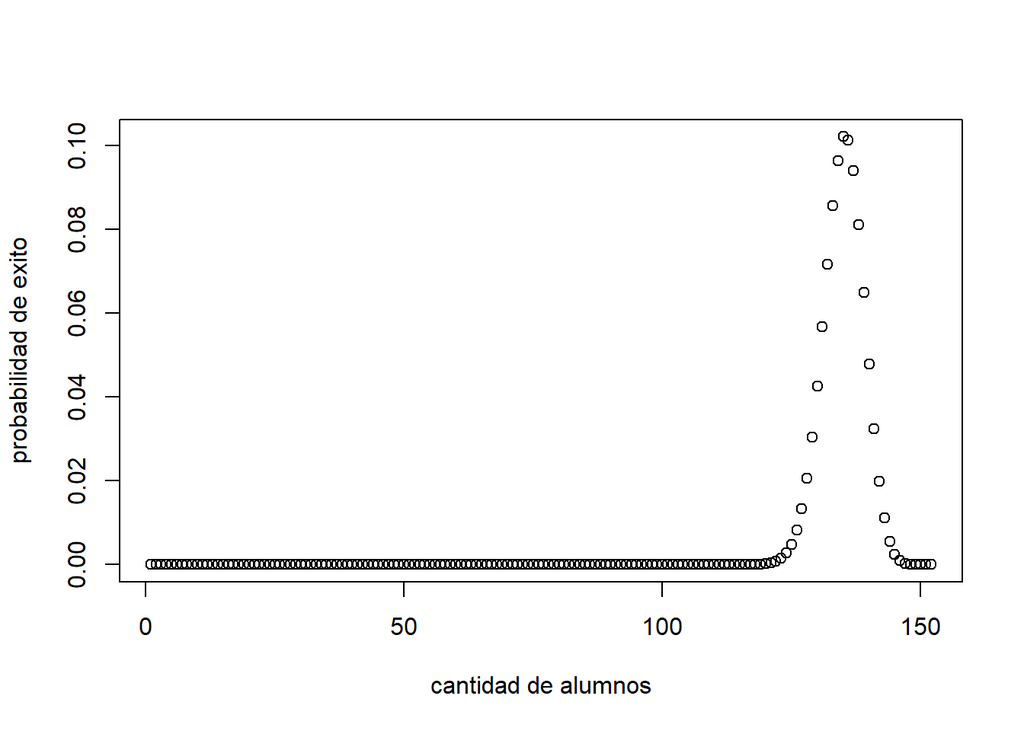

```r
x = 1:152

plot(dbinom(x, 152,as.numeric(probC[2])), ylab = "probabilidad de exito", xlab = "cantidad de alumnos")
```

Funcion de densidad cumulativa:

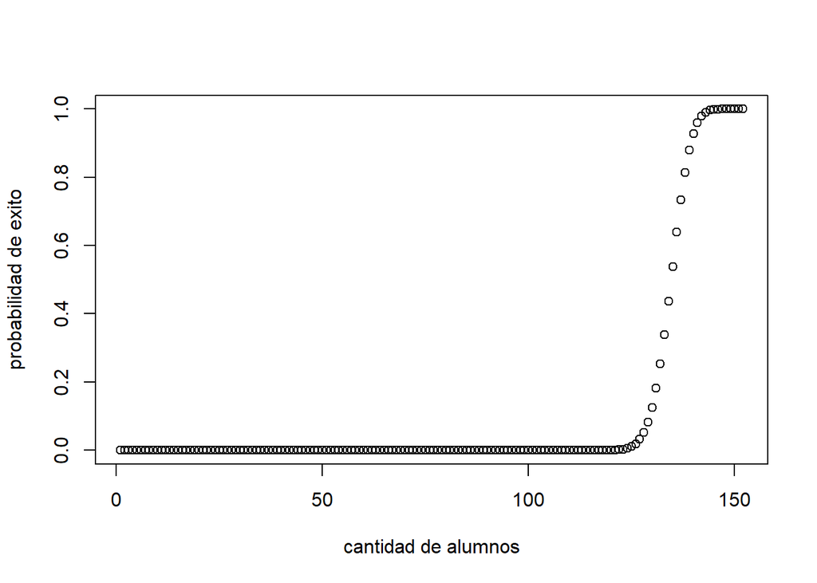

```r
plot(pbinom(x, 152,as.numeric(probC[2])), ylab = "probabilidad de exito", xlab = "cantidad de alumnos")
```

Esperanza:

```r
as.numeric(152*probC[2])
```

```
## [1] 135
```

Varianza:

```r
as.numeric(152*probC[2]*(1-probC[2]))
```

```
## [1] 15.09868
```

Ejemplo:

```r
 1 - pbinom(99, 152, as.numeric(probC[2]))
```

```
## [1] 1
```

## Variables continuas

### Primera variable

Escojemos la distancia entre el hogar del estudiante y la utec- Distancia_UTEC_entre_CASA

Verificamos que modelo de distribución es

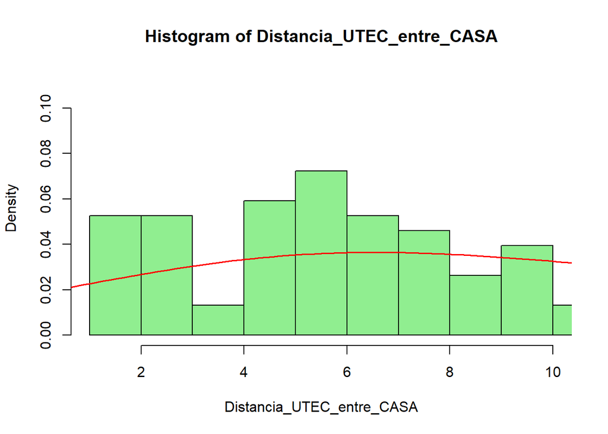

```r
hist(Distancia_UTEC_entre_CASA, prob = TRUE, col = "lightgreen", breaks = 30, xlim = c(1, 10), ylim = #c(0, 1/20)
       )


lines(density(Distancia_UTEC_entre_CASA), lwd = 1.5, col = "red")
```

Observamos que no hay una campana. Asi que asumimos un caso en el que si lo sea

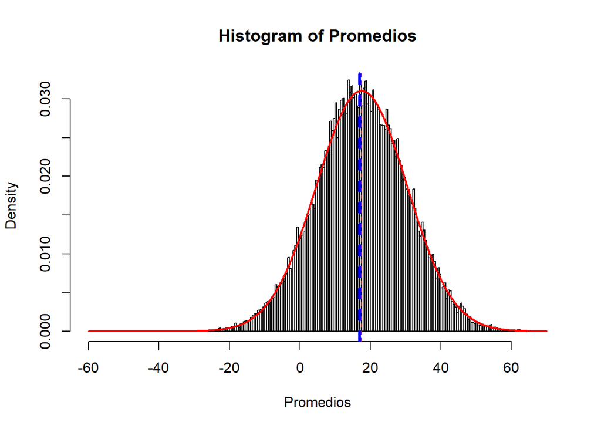

```r
#asumimos una distribucion normal
sdDistancia = sd(Distancia_UTEC_entre_CASA)
meanDistancia = mean(Distancia_UTEC_entre_CASA)
rPromedio <- function(n){
  X <- rnorm(n, mean = meanDistancia, sd = sdDistancia)
    return(mean(X))
}
Promedios <- replicate(30000, rPromedio(1))

hist(Promedios, prob = TRUE, breaks = 152, xlim = c(-60, 70), ylim = #c(0, 1/20)
     )
Xs <- seq(-60, 70, by = 0.1)

lines(Xs, dnorm(Xs, mean = meanDistancia, sd = sdDistancia), col = "red", lwd = 2)
abline(v = c(17, mean(Promedios)), col = c("blue","red"), lty = 2, lwd = c(3, 1))
```

Vemos que posee forma de campana.

Realizamos las validaciones de la distrubucion normal a traves de sus propiedades.

```r
mean(Promedios)
```

```
## [1] 17.50916
```

```r
median(Distancia_UTEC_entre_CASA)
```

```
## [1] 14.75
```

```r
var(Promedios)
```

```
## [1] 163.8074
```

```r
sd(Distancia_UTEC_entre_CASA)^2
```

```
## [1] 165.1664
```

```r
weighted.mean(Promedios)
```

```
## [1] 17.50916
```

```r
mean(Distancia_UTEC_entre_CASA)
```

```
## [1] 17.51941
```

Los parametros:

->X~N(µ, σ)

```r
µ  = weighted.mean(Promedios)
σ = var(Promedios)

µ
```

```
## [1] 17.50916
```

```r
σ
```

```
## [1] 163.8074
```

Ejemplo:

Si un estudiante de la utec es selecionado al azar cual es la probabilidad de que la distancia entre su casa y la universidad sea mayor a 10 km

```r
1-pnorm(10, µ, σ)
```

```
## [1] 0.5182817
```

### Segunda variable

Escojemos la variable tiempo de estudio (horas_de_estudio_por_persona_al_dia )

Verificamos que modelo de distribución es.

Variable: tiempo de estudio.

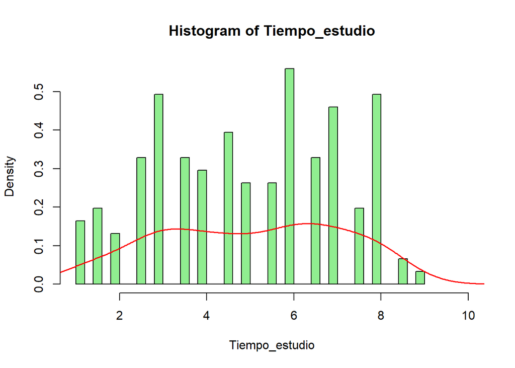

```r
Tiempo_estudio = horas_de_estudio_por_persona_al_dia
hist(Tiempo_estudio, prob = TRUE, col = "lightgreen", breaks = 30, xlim = c(1, 10), ylim = #c(0, 1/20)
    )
lines(density(Tiempo_estudio), lwd = 1.5, col = "red")
```

Observamos que no hay una campana. Asi que asumimos un caso en el que si lo sea.

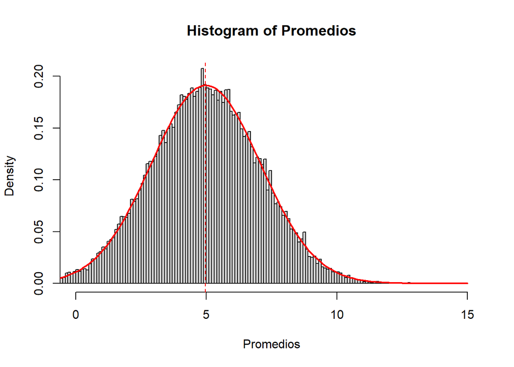

```r
sdTiempo = sd(Tiempo_estudio)
meanTiempo = mean(Tiempo_estudio)
rPromedio <- function(n){
  X <- rnorm(n, mean = meanTiempo, sd = sdTiempo)
    return(mean(X))
}
Promedios <- replicate(30000, rPromedio(1))

hist(Promedios, prob = TRUE, breaks = 152, xlim = c(0, 15), ylim = #c(0, 1/20)
     )
Xs <- seq(-1, 15, by = 0.1)

lines(Xs, dnorm(Xs, mean = meanTiempo, sd = sdTiempo), col = "red", lwd = 2)
abline(v = c(17, mean(Promedios)), col = c("blue","red"), lty = 2, lwd = c(3, 1))
```

vemos que posee forma de campana.

Realizamos las validaciones de la distrubucion normal a traves de sus propiedades.

```r
mean(Promedios)
```

```
## [1] 4.964884
```

```r
median(Tiempo_estudio)
```

```
## [1] 5
```

```r
var(Promedios)
```

```
## [1] 4.34719
```

```r
sd(Tiempo_estudio)^2
```

```
## [1] 4.350601
```

```r
weighted.mean(Promedios)
```

```
## [1] 4.964884
```

```r
mean(Tiempo_estudio)
```

```
## [1] 4.980263
```

Vemos que la media de la variable aleatoria y la mediana de la variable original son casi iguales, pasando lo mismo con la esperanza de la variable aleatoria y la media de la variable de la base de datos y su Varianza y desviacion estandar al cuadrado se aproximan tambien, asi que se presenta una distribucion normal.

Los parametros:

->X~N(µ, σ)

```r
 µ = mean(Tiempo_estudio)
 σ = sd(Tiempo_estudio)

 µ
```

```
## [1] 4.980263
```

```r
 σ
```

```
## [1] 2.085809
```

Ejemplo:

```r
meanTiempo <- 17
sdTiempo <- 11

probabilidad <- pnorm(20, mean = meanTiempo, sd = sdTiempo)

probabilidad
```

```
## [1] 0.6074686
```